# TugasTextMining

Novan & Fadhel

2024-05-30

```r
library("tm")
```

```r
library("SnowballC")
library("wordcloud")
library("RColorBrewer")
library("ggplot2")
library("dplyr")
filePath <- "dataset/rafah.txt"
text <- readLines(filePath)
```

```r
docs <- Corpus(VectorSource(text))
inspect(docs)
```

```
## <<SimpleCorpus>>
## Metadata:  corpus specific: 1, document level (indexed): 0
## Content:  documents: 14
##
##  [1] Wilayah Rafah diserang, pasukan pendudukan israehell mengebom tenda2 yg penuh dgn pengungsi di Rafah. Banyak warga Palestina yang dibakar hidup-hidup.
##  [2] kenapa kita semua Harus All eyes on rafah Karena beberapa kejadian ini membuat Banyak saudara kita dipalestina benar2 Membuntuhkan suara kita. #ALLEYESONRAFAH
##  [3]
##  [4] Rekaman video yang diperoleh Reuters menunjukkan api berkobar dalam kegelapan dan orang-orang berteriak panik. Sekelompok pemuda mencoba menarik lembaran besi bergelombang dan selang dari sebuah truk pemadam kebakaran mulai memadamkan api. Lebih dari separuh korban tewas. #ALLEYESONRAFAH
##  [5]
##  [6] Serangan Israel ke Rafah membakar hidup-hidup pengungsi di tenda. Aksi keji itu terjadi Minggu (26/5/2024), keluarga-keluarga Palestina langsung bergegas ke rumah sakit untuk mempersiapkan jenazah dimakamkan. Serangan Israel membakar tenda-tenda dan tempat perlindungan logam. #ALLEYESONRAFAH
##  [7]
##  [8] Tempat pengungsi di rafah terbakar. #ALLEYESONRAFAH
##  [9]
## [10] Kecam doang gada aksi sama aja, PBB mending bubarin ga guna asli. Konflik bertahun tahun jutaan nyawa ilang. #ALLEYESONRAFAH
## [11] Ini bukan butuh suara lagi, ini harus ada tindakan. negara internasional membiarkan mereka berjuang sendiri setiap kalimat mereka hanya utarakan, hukum internasional juga udah ga berlaku untuk Israel. Jadi, pak putin gapapa kalau israel di bom dan dihilangkan di peta.
## [12] Semuanya mau di serang mau di hancurin, jahat banget asli udh bukan manusia lagi gak punya hati Nurani. #ALLEYESONRAFAH
## [13]
## [14] Gua gak paham sih kenapa bisa kemaren russia di kecam sana sini, dan russia kayanya cuman nyerang pangkalan militer aja kemaren, sampe kena segitu nya sama PBB, ini israel yg udah jelas2 ngelakuin genocide PBB nya diem aja gak ada gerakan apa2 asli ini sih sakit hati liatnya. #ALLEYESONRAFAH
```

```r
toSpace <- content_transformer(function (x , pattern ) gsub(pattern, " ", x))
docs <- tm_map(docs, toSpace, "/")
docs <- tm_map(docs, toSpace, "@")
docs <- tm_map(docs, toSpace, "\\|")
inspect(docs)
```

```
## <<SimpleCorpus>>
## Metadata:  corpus specific: 1, document level (indexed): 0
## Content:  documents: 14
##
##  [1] Wilayah Rafah diserang, pasukan pendudukan israehell mengebom tenda2 yg penuh dgn pengungsi di Rafah. Banyak warga Palestina yang dibakar hidup-hidup.
##  [2] kenapa kita semua Harus All eyes on rafah Karena beberapa kejadian ini membuat Banyak saudara kita dipalestina benar2 Membuntuhkan suara kita. #ALLEYESONRAFAH
##  [3]
##  [4] Rekaman video yang diperoleh Reuters menunjukkan api berkobar dalam kegelapan dan orang-orang berteriak panik. Sekelompok pemuda mencoba menarik lembaran besi bergelombang dan selang dari sebuah truk pemadam kebakaran mulai memadamkan api. Lebih dari separuh korban tewas. #ALLEYESONRAFAH
##  [5]
##  [6] Serangan Israel ke Rafah membakar hidup-hidup pengungsi di tenda. Aksi keji itu terjadi Minggu (26 5 2024), keluarga-keluarga Palestina langsung bergegas ke rumah sakit untuk mempersiapkan jenazah dimakamkan. Serangan Israel membakar tenda-tenda dan tempat perlindungan logam. #ALLEYESONRAFAH
##  [7]
##  [8] Tempat pengungsi di rafah terbakar. #ALLEYESONRAFAH
##  [9]
## [10] Kecam doang gada aksi sama aja, PBB mending bubarin ga guna asli. Konflik bertahun tahun jutaan nyawa ilang. #ALLEYESONRAFAH
## [11] Ini bukan butuh suara lagi, ini harus ada tindakan. negara internasional membiarkan mereka berjuang sendiri setiap kalimat mereka hanya utarakan, hukum internasional juga udah ga berlaku untuk Israel. Jadi, pak putin gapapa kalau israel di bom dan dihilangkan di peta.
## [12] Semuanya mau di serang mau di hancurin, jahat banget asli udh bukan manusia lagi gak punya hati Nurani. #ALLEYESONRAFAH
## [13]
## [14] Gua gak paham sih kenapa bisa kemaren russia di kecam sana sini, dan russia kayanya cuman nyerang pangkalan militer aja kemaren, sampe kena segitu nya sama PBB, ini israel yg udah jelas2 ngelakuin genocide PBB nya diem aja gak ada gerakan apa2 asli ini sih sakit hati liatnya. #ALLEYESONRAFAH
```

```r
# Convert the text to lower case
docs <- tm_map(docs, content_transformer(tolower))
# Remove numbers
docs <- tm_map(docs, removeNumbers)
# specify your stopwords as a character vector
docs <- tm_map(docs, removeWords, c("ini", "dan"))
# Remove punctuations
docs <- tm_map(docs, removePunctuation)
# Eliminate extra white spaces
docs <- tm_map(docs, stripWhitespace)
# Text stemming
# docs <- tm_map(docs, stemDocument)
```

```r
dtm <- TermDocumentMatrix(docs)
m <- as.matrix(dtm)
v <- sort(rowSums(m),decreasing=TRUE)
d <- data.frame(word = names(v),freq=v)
head(d, 10)
```

```
##                          word freq
## alleyesonrafah alleyesonrafah    7
## rafah                   rafah    5
## israel                 israel    5
## pengungsi           pengungsi    3
## kita                     kita    3
## aja                       aja    3
## asli                     asli    3
## pbb                       pbb    3
## gak                       gak    3
## banyak                 banyak    2
```

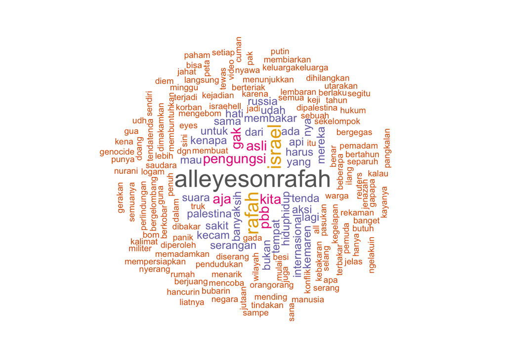

```r
set.seed(1234)
library(wordcloud)

wordcloud(words = d$word, freq = d$freq, min.freq = 1,scale = c(2, 0.5),
          random.order=FALSE, rot.per=0.35,
          colors=brewer.pal(8, "Dark2"))
```

```r
library(wordcloud2)
wordcloud2(data=d, size=0.4, color='random-dark')
```

[interactive chart not shown]

Perbedaan wordcloud() dan wordcloud2() di parameternya wordcloud() memiliki parameter words = merupakan data word, freq = merupakan frekuensi dari data word, scale = digunakan untuk rezise plot word, min.freq = frekuensi minimal dari word yang akan di plot, max.word = maksimal word yang akan di plot, random.order = menentukan acak tidaknya plot, jika TRUE tulisan yang memiliki freq tinggi akan tersebar tidak hanya di tengah, random.color = menentukan random tidaknya warna dari word yang akan di plot, rot.per = menentukan probabilitas word yang akan di rotate di plot, colors = list warna yang akan digunakan di word, ordered.colors = true/false random urutan dari warna,

sedangkan wordcloud2() memiliki parameter data = merupakan data yang secara otomatis mencari word dan frekuensi, size = ukuran plot, minSize = minimal ukuran plot, gridSize = menentukan besar jarak antar word, fontFamily = font dari word, fontWeight = ketebalan font, color = tema warna yang dipakai, backgroundColor = warna background, minRotation = minimal rotasi word, maxRotation = maksimal rotasi word, shuffle = acak/tidaknya, rotateRatio = rasio rotasi, shape = bentuk shape dari plot, ellipticity = radius/rounded dari plot,

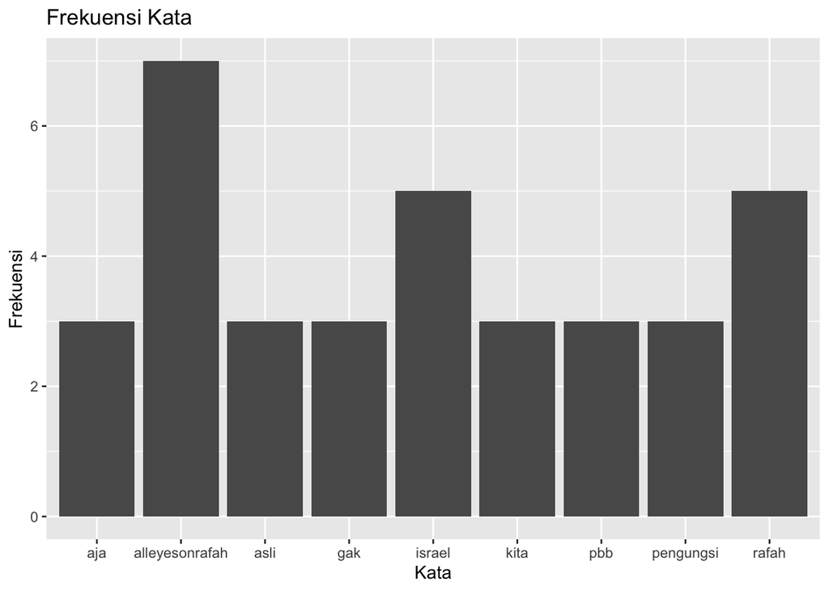

```r
ggplot(d %>% filter(freq > 2), aes(x = word, y=freq )) +
  geom_col(position = position_dodge(5)) +  # Ubah posisi label
  labs(title = "Frekuensi Kata", x = "Kata", y = "Frekuensi") +  # Tambahkan judul dan label
  theme()
```